# ---{Módulo 9}--- Geometria Plana -----

#### $$ \text{---\{ Proporcionalidades \}---} \\[24pt] $$

### $$ \text{Teorema da Bissetriz} $$

$$ \text{Prof. Eduardo Ono} \\[24pt] $$

**Sumário**

- 1. Objetivos
- 1. Teoremas da Bissetriz
  - 2.1. Teorema da Bissetriz Interna

# 1. Objetivos

- Conceituar o Teorema da Bissetriz;
- Enunciar e demonstrar o Teorema da Bissetriz;
- Aplicar os conceitos na resolução de problemas.

# 2. Teoremas da Bissetriz

Se duas retas são transversais de um feixe de retas paralelas, então a razão entre dois segmentos quaisquer de uma delas é igual à razão entre os respectivos segmentos correspondentes da outra.

## 2.1. Teorema da Bissetriz Interna

Uma **bissetriz interna** de um triângulo divide o lado oposto em segmentos (aditivos) proporcionais aos lados adjacentes.

O enunciado acima deve ser entendido como segue.

$$ \boxed{\ \cfrac{\,m\,}{c} = \cfrac{\;n\;}{b}\ } $$

Demonstração.

Hipótese: $\overline{AD}$ é bissentriz interna do $\triangle ABC$.

Tese: $\cfrac{\,m\,}{c} = \cfrac{\;n\;}{b}$

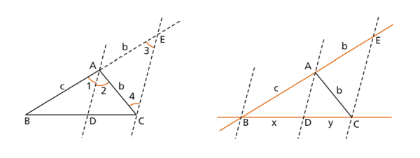

Fonte: Iezzi

Conduzimos por $C$ uma paralela à bissetriz $\,\overline{AD}\,$, determinando um ponto $E$ na reta $\,\overleftrightarrow{AB}\,$, de modo que $\,\overline{CE}\, /\negmedspace/\, \overline{AD}\,$.

Os ângulos $\,B\hat{A}D\,$ e $\,A\hat{E}C\,$ são correspondentes e os ângulos $\,D\hat{A}C\,$ e $\,A\hat{C}E\,$ são alternos internos. Por hipótese, os ângulos $\,B\hat{A}D\,$ e $\,D\hat{A}C\,$ são congruentes. Decorre que os ângulos $\,A\hat{E}C\,$ e $\,E\hat{C}A\,$ são congruentes, caracterizando o triângulo $ACE$, de base $\,\overline{CE}\,$, como isósceles. Temos, então:

$$ \overline{AC} \equiv \overline{AE}\,. $$

Aplicando o teorema de Tales, vem:

$$ \cfrac{\overline{BD}}{\overline{BA}} = \cfrac{\overline{DC}}{\overline{AE}} \implies \cfrac{\overline{BD}}{\overline{BA}} = \cfrac{\overline{DC}}{\overline{AC}} \\ $$

Portanto,

$$ \boxed{\cfrac{\ m\ }{\ c\ } = \cfrac{\ n\ }{\ b\ }\,}. $$